# Case study and typical operations with base R

Advanced R

Wednesday May 2, 2018

## Learning goals

1. Introduce mass spectrometry data and common data analysis tasks for the case study.
2. Review tools in base R for the tasks.

## A typical bottom-up MS-based proteomics experiment

- Design: to compare **protein** abundance between **groups** of interest (e.g., healthy vs. diseased subjects).
- Measurements: **feature intensities** measured by mass spectrometry
  - **Proteins** are cleaved into peptides.
  - **Peptides** are charged, fragmented and measured by mass spectrometry.
  - **Features** (fragments of charged peptides) are the basic unit of quantification.

```r
load("adv-R-twin.RData")
```

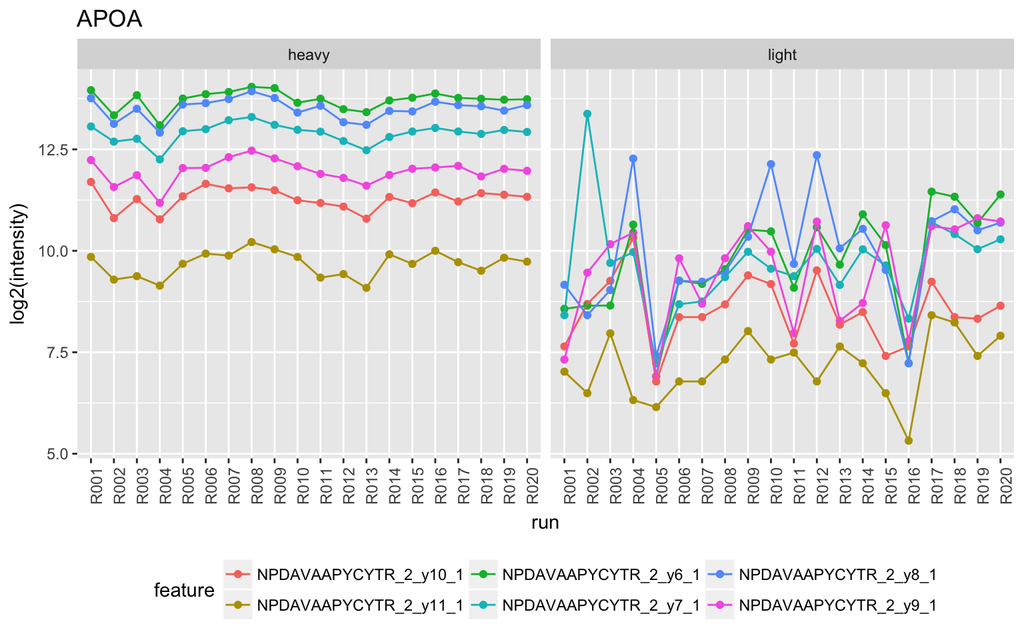

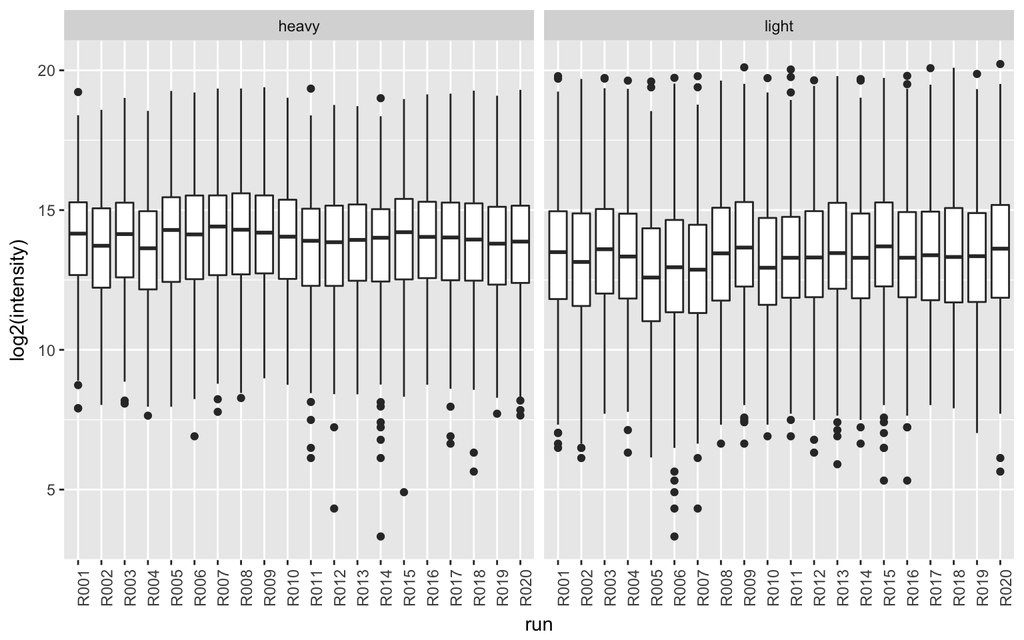

## Case study

Liu et al., Quantitative variability of 342 plasma proteins in a human twin population, *Molecular Systems Biology*, 2015. [PMID: 25652787]

- The dataset contains 232 MS runs of plasma samples:
  - 58 pairs of monozygotic (MZ) and dizygotic (DZ) twins
  - 2 time points
  - $58 \times 2 \times 2 = 232$
- Data were acquired with two MS workflows:
  - data independent acquisition (DIA)
  - selected reaction monitoring (SRM)
- We use a subset of the original dataset (with 33 proteins by DIA and 39 proteins by SRM).

```r
str(twin_dia)
```

```
## 'data.frame':    103936 obs. of  9 variables:
##  $ protein    : chr  "A1AG_BOVINE" "A1AG_BOVINE" "A1AG_BOVINE" "A1AG_BOVINE" ...
##  $ feature    : chr  "AIQAAFFYLEPR_2_y3_1" "AIQAAFFYLEPR_2_y3_1" "AIQAAFFYLEPR_2_y3_1" "AIQAAFFYLEPR_2_y3_1" ...
##  $ run        : chr  "R001" "R002" "R003" "R004" ...
##  $ pair       : int  1 1 1 1 2 2 2 2 3 3 ...
##  $ zygosity   : Factor w/ 2 levels "DZ","MZ": 2 2 2 2 2 2 2 2 2 2 ...
##  $ subject    : int  1 1 2 2 3 3 4 4 5 5 ...
##  $ visit      : int  1 2 1 2 1 2 1 2 1 2 ...
##  $ intensity_h: num  NA NA NA NA NA NA NA NA NA NA ...
##  $ intensity_l: num  27742 31572 24084 33134 23468 ...
```

The two data frames have the same format, containing 9 columns:

- `protein` (chr): protein name
- `feature` (chr): combination of peptide, precursor charge state, fragment ion, and product charge state, separated by `_`
- `run` (chr): MS run identifier (R001-R232)
- `pair` (int): pair identifier number (1-58)
- `zygosity` (factor): zygosity (MZ, DZ)
- `subject` (int): subject identifier number (1-116)
- `visit` (int): time of visit (1, 2)
- `intensity_l` (num): integrated feature intensity from light (L) channel
- `intensity_h` (num): integrated feature intensity from heavy (H, aka reference) channel

```r
head(twin_dia)
```

```
##       protein             feature  run pair zygosity subject visit
## 1 A1AG_BOVINE AIQAAFFYLEPR_2_y3_1 R001    1       MZ       1     1
## 2 A1AG_BOVINE AIQAAFFYLEPR_2_y3_1 R002    1       MZ       1     2
## 3 A1AG_BOVINE AIQAAFFYLEPR_2_y3_1 R003    1       MZ       2     1
## 4 A1AG_BOVINE AIQAAFFYLEPR_2_y3_1 R004    1       MZ       2     2
## 5 A1AG_BOVINE AIQAAFFYLEPR_2_y3_1 R005    2       MZ       3     1
## 6 A1AG_BOVINE AIQAAFFYLEPR_2_y3_1 R006    2       MZ       3     2
##   intensity_h intensity_l
## 1          NA       27742
## 2          NA       31572
## 3          NA       24084
## 4          NA       33134
## 5          NA       23468
## 6          NA       27247
```

```r
class(twin_dia)
```

```
## [1] "data.frame"
```

A **data frame** contains **variables** (in **columns**) and **observations** (in **rows**) in a tabular form. It is essentially a **list** of vectors of equal length. The columns in a data frame have the same length, but they may represent different types of variables (e.g., numeric, character, logical, etc.). Data frames are preferable in most analysis tasks because:

- Data frame keeps together related values of variables (in a row).
- Most functions for statistical modeling, inference and graphing in R take data frame as a primary input format, passed through a `data =` argument.

Dimension of the data:

```r
dim(twin_dia)
nrow(twin_dia)
ncol(twin_dia)
```

Level of the categorical variable:

```r
levels(twin_dia$zygosity)
```

`View()` calls the data viewer in RStudio.

```r
View(twin_dia)
```

## Data analysis tasks for the case study

- **Task 1:** compute the median of log-intensities for features from the heavy channel in each run.
- **Task 2:** normalization of feature intensities to remove systematic bias across runs.
- **Task 3:** summarization of feature intensities for each protein in every run.
- **Task 4:** fit a linear model to characterize the summarized intensities.
- **Task 5:** group comparison using model-based inference.

While R offers several tools that can be applied for each task, it is important to note how they can (or cannot) be integrated into a consistent workflow.

## Task 1: median of log-intensities (heavy channel) per run

This is a very common data analysis task: making grouped summaries, which involves application of the **split-apply-combine** approach. Let’s begin with a review of necessary tools for data manipulation and transformation.

### Data manipulation and transformation

Three common operations:

- Extract existing variables (with `$`, column names, or indices).
- Extract existing observations (with logical operations on the variables).
- Add new variables.

#### Extract existing variables

Keep only a subset of variables relevant to the analysis. For example, to create a look-up table for sample annotation:

```r
colnames(twin_dia)
```

```
## [1] "protein"     "feature"     "run"         "pair"        "zygosity"
## [6] "subject"     "visit"       "intensity_h" "intensity_l"
```

```r
# Extract columns for sample annotation
design <- unique(twin_dia[, c("run", "pair", "zygosity", "subject", "visit")])
head(design)
```

```
##    run pair zygosity subject visit
## 1 R001    1       MZ       1     1
## 2 R002    1       MZ       1     2
## 3 R003    1       MZ       2     1
## 4 R004    1       MZ       2     2
## 5 R005    2       MZ       3     1
## 6 R006    2       MZ       3     2
```

#### Extract existing observations with logical operations

Extract observations based on values in specific columns:

```r
# Exclude rows with NA in column intensity_h
sub_dia <- twin_dia[!is.na(twin_dia$intensity_h), ]
head(sub_dia)
```

```
##      protein                           feature  run pair zygosity subject
## 6729    A2MG SSSNEEVM(UniMod_35)FLTVQVK_2_y4_1 R001    1       MZ       1
## 6730    A2MG SSSNEEVM(UniMod_35)FLTVQVK_2_y4_1 R002    1       MZ       1
## 6731    A2MG SSSNEEVM(UniMod_35)FLTVQVK_2_y4_1 R003    1       MZ       2
## 6732    A2MG SSSNEEVM(UniMod_35)FLTVQVK_2_y4_1 R004    1       MZ       2
## 6733    A2MG SSSNEEVM(UniMod_35)FLTVQVK_2_y4_1 R005    2       MZ       3
## 6734    A2MG SSSNEEVM(UniMod_35)FLTVQVK_2_y4_1 R006    2       MZ       3
##      visit intensity_h intensity_l
## 6729     1        6687        1275
## 6730     2        5799        1345
## 6731     1        6093        1377
## 6732     2        6049        1727
## 6733     1        7068         922
## 6734     2        5401         720
```

Combine multiple logical operations:

- element-wise AND operation with `&`
- element-wise OR operation with `|`

```r
# Filter based on columns intensity_h and run
sub_dia <- twin_dia[!is.na(twin_dia$intensity_h) & twin_dia$run == "R001", ]
head(sub_dia)
```

```
##      protein                           feature  run pair zygosity subject
## 6729    A2MG SSSNEEVM(UniMod_35)FLTVQVK_2_y4_1 R001    1       MZ       1
## 6961    A2MG SSSNEEVM(UniMod_35)FLTVQVK_2_y5_1 R001    1       MZ       1
## 7193    A2MG SSSNEEVM(UniMod_35)FLTVQVK_2_y7_1 R001    1       MZ       1
## 7425    A2MG SSSNEEVM(UniMod_35)FLTVQVK_2_y8_1 R001    1       MZ       1
## 7657    A2MG SSSNEEVM(UniMod_35)FLTVQVK_2_y9_1 R001    1       MZ       1
## 7889    A2MG           SSSNEEVMFLTVQVK_2_y10_1 R001    1       MZ       1
##      visit intensity_h intensity_l
## 6729     1        6687        1275
## 6961     1       11720        2485
## 7193     1        4791        1144
## 7425     1        6496        1457
## 7657     1        4615        1074
## 7889     1        2464        1630
```

#### Add new variables

```r
# Log2 transformation
twin_dia$log2inty_h <- log2(twin_dia$intensity_h)
twin_dia$log2inty_l <- log2(twin_dia$intensity_l)
```

#### Combine multiple operatons

Compute the median of feature intensities from the heavy channel (`log2inty_h`) in one run (`R001`):

```r
median(twin_dia$log2inty_h[!is.na(twin_dia$log2inty_h) & twin_dia$run == "R001"])
```

```
## [1] 14.15806
```

There are two issues when combining multiple operations with functions in base R:

1. The name of the data frame is repeated several times. This can be avoided by using `with()`, as in `with(twin_dia, median(log2inty_h[!is.na(log2inty_h) & run == "R001"]))`.
2. The **nested representation** makes the flow of operation less readable and thus error-prone. Creating intermediate objects may be helpful if the objects are named properly (naming itself can be hard though).

### The split-apply-combine approach

A very common pattern to make grouped summaries:

- **Split** a vector `X` into subsets defined by a group-indication vector `GROUP`.
- **Apply** function `FUN` to each subset.
- **Combine** the results and return in a convenient form.

In Task 1, to compute the medians of log-intensities in all runs, we need to split the column vector `log2inty_h` into subsets defined by `run`, apply `median()` to each subset, and combine the results.

### Approach 1a: use a `for` loop

```r
# Approach 1a
runs <- unique(twin_dia$run)

medians <- rep(0, length(runs))  # create a vector to restore the result
for (i in seq_along(runs)) {
    medians[i] <- median(twin_dia$log2inty_h[twin_dia$run == runs[i]], na.rm = TRUE)
}
str(medians)
```

```
##  num [1:232] 14.2 13.7 14.1 13.6 14.3 ...
```

### Approach 1b: use `tapply()`

Syntax: `tapply(X, GROUP, FUN)`.

```r
# Approach 1b
medians <- tapply(twin_dia$log2inty_h, twin_dia$run, median, na.rm = TRUE)
head(medians)  # a named vector is returned
```

```
##     R001     R002     R003     R004     R005     R006
## 14.15806 13.72355 14.14139 13.63368 14.28807 14.12904
```

### Approach 1c: use `aggregate()`

Syntax: `aggregate(X, GROUP, FUN)`.

```r
# Approach 1c
df_median <- aggregate(twin_dia$log2inty_h, list(run = twin_dia$run), median, na.rm = TRUE)
head(df_median)  # a data frame is returned
```

```
##    run        x
## 1 R001 14.15806
## 2 R002 13.72355
## 3 R003 14.14139
## 4 R004 13.63368
## 5 R005 14.28807
## 6 R006 14.12904
```

```r
# Rename second column for later use
colnames(df_median)[2] <- "run_median"
```

`tapply()` and `aggregate()` are tools for **functional programming** that will be discussed in greater detail in a later session. Note that their outputs are of different classes.

## Task 2: normalization

Adjust the log-intensities to equalize the medians across runs to a global median:

```r
(gbl_median <- median(medians, na.rm = TRUE))
```

```
## [1] 14.04896
```

### Approach 2a: use a `for` loop

```r
# Use a for loop
for (ii in names(medians)) {
    log2inty_h <- twin_dia$log2inty_h[twin_dia$run == ii]
    log2inty_l <- twin_dia$log2inty_l[twin_dia$run == ii]
    twin_dia$log2inty_h[twin_dia$run == ii] <- log2inty_h - medians[ii] + gbl_median
    twin_dia$log2inty_l[twin_dia$run == ii] <- log2inty_l - medians[ii] + gbl_median
}
```

```r
# Check the normalized medians
head(tapply(twin_dia$log2inty_h, twin_dia$run, median, na.rm = TRUE))
```

```
##     R001     R002     R003     R004     R005     R006
## 14.04896 14.04896 14.04896 14.04896 14.04896 14.04896
```

```r
# Back to unnormalized values for Approach 2b
twin_dia$log2inty_h <- log2(twin_dia$intensity_h)
twin_dia$log2inty_l <- log2(twin_dia$intensity_l)
```

### Approach 2b: use a vectorized representation

A more efficient way is to use a vectorized representation with the named vector returned by `tapply()`:

```r
# This gives the medians of runs R001, R002, R003, R001
medians[c("R001", "R002", "R003", "R001")]
```

```
##     R001     R002     R003     R001
## 14.15806 13.72355 14.14139 14.15806
```

```r
# Use vectorized representation to normalize the dataset
twin_dia$log2inty_h <- twin_dia$log2inty_h - medians[twin_dia$run] + gbl_median
twin_dia$log2inty_l <- twin_dia$log2inty_l - medians[twin_dia$run] + gbl_median
```

```r
# Check the normalized medians
head(tapply(twin_dia$log2inty_h, twin_dia$run, median, na.rm = TRUE))
```

```
##     R001     R002     R003     R004     R005     R006
## 14.04896 14.04896 14.04896 14.04896 14.04896 14.04896
```

```r
# Back to unnormalized values for Approach 2c
twin_dia$log2inty_h <- log2(twin_dia$intensity_h)
twin_dia$log2inty_l <- log2(twin_dia$intensity_l)
```

### Approach 2c: merge computed medians to original data frame

We can also add one column for the median in each run (from `df_median` returned by `aggregate()`) to the original data frame `twin_dia`, with `merge()`.

The operation `merge(X, Y, by.x = "X_COL", by.y = "Y_COL")` joins two data frames `X`, `Y`, by matching the columns `X_COL` and `Y_COL`.

- Default (when `by.x` and `by.y` are not specified) is to match all columns with common names.
- It returns a new data frame that has all the columns in `X` and `Y`.

```r
twin_dia2 <- merge(x = twin_dia, y = df_median)
head(twin_dia2)
```

```
##    run     protein                           feature pair zygosity subject
## 1 R001 A1AG_BOVINE               AIQAAFFYLEPR_2_y3_1    1       MZ       1
## 2 R001        TTHY             GSPAINVAVHVFR_3_y11_3    1       MZ       1
## 3 R001 A1AG_BOVINE                 EHFVDLLLSK_2_y9_2    1       MZ       1
## 4 R001        A2MG SSSNEEVM(UniMod_35)FLTVQVK_2_y9_1    1       MZ       1
## 5 R001         IC1         GVTSVSQIFHSPDLAIR_3_y14_2    1       MZ       1
## 6 R001       APOA1              DYVSQFEGSALGK_2_y9_1    1       MZ       1
##   visit intensity_h intensity_l log2inty_h log2inty_l run_median
## 1     1          NA       27742         NA   14.75978   14.15806
## 2     1       33067      105041   15.01310   16.68059   14.15806
## 3     1          NA        2220         NA   11.11634   14.15806
## 4     1        4615        1074   12.17211   10.06878   14.15806
## 5     1       33692       21186   15.04012   14.37082   14.15806
## 6     1       63146      127581   15.94640   16.96105   14.15806
```

```r
twin_dia2$log2inty_h <- twin_dia2$log2inty_h - twin_dia2$run_median + gbl_median
twin_dia2$log2inty_l <- twin_dia2$log2inty_l - twin_dia2$run_median + gbl_median

head(tapply(twin_dia2$log2inty_h, twin_dia2$run, median, na.rm = TRUE))
```

```
##     R001     R002     R003     R004     R005     R006
## 14.04896 14.04896 14.04896 14.04896 14.04896 14.04896
```

## Task 3: summarization of feature intensities

For each **protein** and each **run**, compute the **log of the sum** of the normalized feature intensities in the light channel.

```r
# Transform the normalized log-intensities back to the original scale
twin_dia2$intensity_h <- 2 ^ (twin_dia2$log2inty_h)
twin_dia2$intensity_l <- 2 ^ (twin_dia2$log2inty_l)
```

### Approach 3a: use two `for` loops

One `for` loop for protein and the other for run. Skipped here.

### Approach 3b: use `tapply()`

Use `tapply()` with grouping variables defined in a **list**:

```r
# Approach 3b
sum_t <- tapply(
    twin_dia2$intensity_l,
    list(run = twin_dia2$run, protein = twin_dia2$protein),
    function(x) log2(sum(x, na.rm = TRUE))
)
head(sum_t)
```

```
##       protein
## run    A1AG_BOVINE     A2MG     AACT      APOA    APOA1     APOB     APOE
##   R001    18.29013 16.53327 17.95957 10.691798 22.53594 15.88951 16.77467
##   R002    18.24357 16.92032 17.45603 13.943098 22.81600 17.23851 17.46524
##   R003    18.43766 16.60592 18.13241 11.787150 22.54608 15.99778 16.86590
##   R004    18.55395 17.32352 17.78989 13.746895 22.82048 17.25128 17.61631
##   R005    17.74911 15.88714 16.92580  9.294212 21.91282 15.03136 15.44820
##   R006    18.45313 15.72619 17.43430 11.461494 22.20341 16.02068 16.63865
##       protein
## run        C1QA     C1QB     C1QC     CFAB     CLUS      CO3     CO4A
##   R001 15.12755 16.89567 14.79553 18.55630 17.78429 19.11825 17.96988
##   R002 14.99429 17.82603 14.33059 19.13234 18.18175 20.65650 18.26374
##   R003 14.95941 16.62140 14.46951 18.57090 18.02119 19.91455 18.02947
##   R004 15.58755 16.62838 14.86023 19.09566 18.33794 20.80271 18.52775
##   R005 13.81209 14.57085 13.50855 17.56370 16.86926 18.56189 17.09983
##   R006 13.64858 16.87396 11.69799 18.17042 17.49998 19.42060 17.80662
##       protein
## run         CO5      CO6      CO7      FN1     GELS      HPT      IC1
##   R001 16.91427 15.01251 13.07546 15.72394 17.69312 22.04630 17.48368
##   R002 16.19937 14.47927 13.22135 15.94671 17.45022 22.30563 18.61671
##   R003 16.96623 15.14171 13.33893 15.78835 17.68185 22.32501 17.67768
##   R004 17.16972 14.72355 13.48069 16.06229 17.83171 22.38493 18.72258
##   R005 15.86150 13.66099 11.79224 14.98560 16.85755 20.88857 17.77094
##   R006 16.25106 14.19938 11.88606 15.35932 17.15612 20.87295 18.09383
##       protein
## run       ITIH4     PLMN     PON1      PZP     RET4     SHBG     TETN
##   R001 17.14894 18.20481 16.73587 19.90868 15.40672 13.45612 15.17536
##   R002 17.40908 18.48714 16.98917 19.63802 15.12063 14.30357 15.07134
##   R003 17.44668 18.18836 16.59767 19.95777 15.66912 13.56934 15.29467
##   R004 17.55675 18.70231 17.30929 20.17364 15.61679 14.26057 15.06099
##   R005 16.05954 17.08028 15.84878 19.35697 14.12714 13.85455 14.37743
##   R006 16.50470 17.62551 16.60008 19.52160 14.57125 12.68188 14.58580
##       protein
## run        THBG     THRB     TRFE     TTHY     VTNC
##   R001 12.23907 18.99845 21.91104 18.37754 19.49643
##   R002 12.73929 18.53500 21.88169 18.10470 19.79280
##   R003 12.79650 19.08148 22.01736 18.50559 19.46675
##   R004 13.10789 18.49619 21.99571 18.81359 19.61810
##   R005 11.23408 17.89837 21.37637 16.87036 18.26991
##   R006 12.26199 18.15906 21.90232 17.63769 18.87719
```

### Approach 3c: use `aggregate()`

```r
# Approach 3c
sum_g <- aggregate(
    twin_dia2$intensity_l,
    list(run = twin_dia2$run, protein = twin_dia2$protein),
    function(x) log2(sum(x, na.rm = TRUE))
)
head(sum_g)
```

```
##    run     protein        x
## 1 R001 A1AG_BOVINE 18.29013
## 2 R002 A1AG_BOVINE 18.24357
## 3 R003 A1AG_BOVINE 18.43766
## 4 R004 A1AG_BOVINE 18.55395
## 5 R005 A1AG_BOVINE 17.74911
## 6 R006 A1AG_BOVINE 18.45313
```

```r
# Alternatively, use a formula representation
sum_g <- aggregate(
    intensity_l ~ run + protein,
    data = twin_dia2,
    function(x) log2(sum(x, na.rm = TRUE))
)
```

```r
# Rename the third column
colnames(sum_g)[3] <- "log2inty"
```

Saving the grouped summaries in a data frame makes it easier to carry out statistical modeling and inference in subsequent analysis.

## Task 4: fit a linear model to characterize summarized intensities

For each **protein**, fit a linear model, extract summaries of the fitted model, and draw model-based inference.

### Fit a linear regression model with `lm()`

The first argument of `lm()` is a formula, e.g., `Y ~ X1 + X2`, where `Y` is the response and `X1`, `X2` are the predictive variables. These refer to the column names (variables) in a data frame, that we pass on to `lm()` through the `data` argument.

Suppose we are interested in knowing if the abundance of one **protein** is associated with **zygosity**.

```r
# Merge the design information
df_sum <- merge(sum_g, design)
head(df_sum)
```

```
##    run     protein log2inty pair zygosity subject visit
## 1 R001 A1AG_BOVINE 18.29013    1       MZ       1     1
## 2 R001        APOB 15.88951    1       MZ       1     1
## 3 R001        CLUS 17.78429    1       MZ       1     1
## 4 R001         CO7 13.07546    1       MZ       1     1
## 5 R001        PLMN 18.20481    1       MZ       1     1
## 6 R001        TETN 15.17536    1       MZ       1     1
```

```r
sub_sum <- df_sum[df_sum$protein == "A2MG", ]  # Subset for protein A2MG
fit <- lm(log2inty ~ zygosity, data = sub_sum)
```

```r
# Same as
fit <- lm(log2inty ~ zygosity, data = df_sum, subset = df_sum$protein == "A2MG")
```

```r
class(fit)
```

```
## [1] "lm"
```

### Utility functions

R offers a couple of utility functions for linear models, such as `coef()`, `fitted()`, `residuals()`, `summary()`, `predict()`, for retrieving coefficients, fitted values, residuals, model summary, making predictions with the model, respectively.

These functions can be applied in the same way for other model objects such as `glm()`, `gam()`, etc.

#### Use `summary()` to display an overview of the fitted model

```r
summary(fit)
```

```
##
## Call:
## lm(formula = log2inty ~ zygosity, data = sub_sum)
##
## Residuals:
##     Min      1Q  Median      3Q     Max
## -2.8459 -0.4717  0.2141  0.5559  1.3189
##
## Coefficients:
##             Estimate Std. Error t value Pr(>|t|)
## (Intercept) 16.22981    0.08232 197.144  < 2e-16 ***
## zygosityMZ   0.30659    0.10449   2.934  0.00368 **
## ---
## Signif. codes:  0 '***' 0.001 '**' 0.01 '*' 0.05 '.' 0.1 ' ' 1
##
## Residual standard error: 0.7723 on 230 degrees of freedom
## Multiple R-squared:  0.03608,    Adjusted R-squared:  0.03189
## F-statistic: 8.609 on 1 and 230 DF,  p-value: 0.003685
```

```r
# More detail
str(summary(fit))
```

#### Use `coef()` to retrieve estimated coefficients

```r
coef(fit)
```

```
## (Intercept)  zygosityMZ
##   16.229805    0.306589
```

#### Use `fitted()` to retrieve fitted values

```r
head(fitted(fit))
```

```
##       29       47       90      117      162      194
## 16.53639 16.53639 16.53639 16.53639 16.53639 16.53639
```

To derive summaries for all the proteins, additional efforts are required to extract relevant information and package them into a convenient format. If we want to avoid using `for` loops, we will need to define specialized functions to extract summaries of interest that can be passed on to `tapply()` or `aggregate()`.

## Task 5: model-based inference

Two-sample $t$-test on the subset of summaries for protein A2MG:

```r
ttest <- t.test(log2inty ~ zygosity, data = sub_sum)
ttest
```

```
##
##  Welch Two Sample t-test
##
## data:  log2inty by zygosity
## t = -2.7956, df = 156.64, p-value = 0.005828
## alternative hypothesis: true difference in means is not equal to 0
## 95 percent confidence interval:
##  -0.52320569 -0.08997232
## sample estimates:
## mean in group DZ mean in group MZ
##         16.22981         16.53639
```

It’s equivalent to use the `subset` option:

```r
t.test(log2inty ~ zygosity, data = df_sum, subset = df_sum$protein == "A2MG")
```

Alternatively, you can use two vectors for the two samples:

```r
t.test(x = sub_sum$log2inty[sub_sum$zygosity == "DZ"], y = sub_sum$log2inty[sub_sum$zygosity == "MZ"])
```

Take a look at the output object:

```r
str(ttest)
```

```
## List of 9
##  $ statistic  : Named num -2.8
##   ..- attr(*, "names")= chr "t"
##  $ parameter  : Named num 157
##   ..- attr(*, "names")= chr "df"
##  $ p.value    : num 0.00583
##  $ conf.int   : num [1:2] -0.523 -0.09
##   ..- attr(*, "conf.level")= num 0.95
##  $ estimate   : Named num [1:2] 16.2 16.5
##   ..- attr(*, "names")= chr [1:2] "mean in group DZ" "mean in group MZ"
##  $ null.value : Named num 0
##   ..- attr(*, "names")= chr "difference in means"
##  $ alternative: chr "two.sided"
##  $ method     : chr "Welch Two Sample t-test"
##  $ data.name  : chr "log2inty by zygosity"
##  - attr(*, "class")= chr "htest"
```

```r
ttest$estimate
```

```
## mean in group DZ mean in group MZ
##         16.22981         16.53639
```

```r
ttest$statistic
```

```
##         t
## -2.795639
```

```r
ttest$p.value
```

```
## [1] 0.005828219
```

As in Task 4, it requires additional efforts to work with model objects, in order to make and combine summaries for all the proteins:

- How would you implement a workflow to summarize the means of two groups, difference, $t$-statistic, $p$-value for every protein?
- Do you see any inconvenience or inconsistency in the workflow? If so, where do they come from?